# Multivariate Relationships with Absolute Deviation (w/o PC)

MPT Reanalysis Project (code and text current document: Henrik Singmann)

Results from: 2021-06-02

# Overview

This document provides an overview of the multivariate relationships of all moderators with the absolute parameter deviation. As in the analysis of the univariate relationships we focus on two reference methods, the complete pooling MLE method and the latent-trait partial pooling method.

In all the analyses reported here, we remove the no pooling Bayes method, as it behaved markedly different from all other methods.

# Correlations and Multicollinearity (all pairs)

When looking at the multivariate relationships, we need to consider the degree of multicollinearity that could be present in the data. The following plot shows the distribution of correlations across all pairs of moderators in the data across each pair of one of the reference methods with each other method. More specifically, each data point underlying the depiction in each row of the figure is the correlation for these two moderators for one pair of methods where in each case at least one of the methods in each pair is one of the two reference methods. The figure then depicts the median of these distribution as a solid point and the error bars depict the minimum and the maximum.

This figure shows that for several of the pairs there is substantial correlation between .25 and .5, but for only one pair is the correlation consistently above .5, with the median just above .75. This is for the two standard errors. Therefore, in the following we combine both standard error estimates into one average.

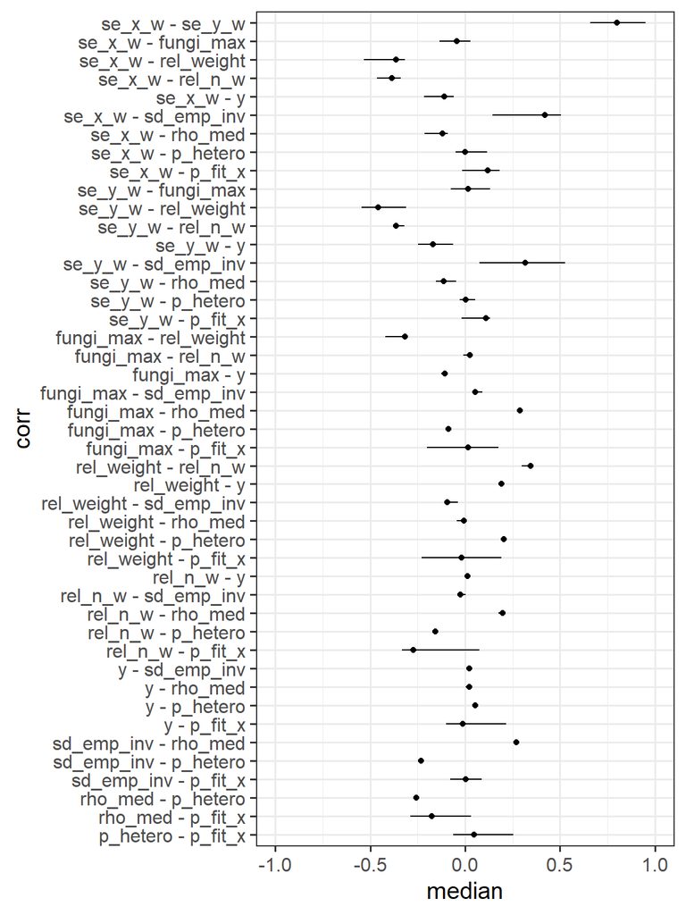

The following table lists some summary statistics of the correlation distribution ordered by largest absolute minimum correlation:

```
## # A tibble: 45 x 6
##    corr                     min    max median  mean     sd
##    <fct>                  <dbl>  <dbl>  <dbl> <dbl>  <dbl>
##  1 se_x_w - se_y_w         0.66  0.95    0.80  0.79 0.082
##  2 se_y_w - rel_weight    -0.55 -0.31   -0.46 -0.46 0.079
##  3 se_x_w - rel_weight    -0.53 -0.32   -0.36 -0.40 0.073
##  4 se_x_w - rel_n_w       -0.46 -0.34   -0.39 -0.39 0.043
##  5 fungi_max - rel_weight -0.42 -0.31   -0.32 -0.33 0.037
##  6 se_y_w - rel_n_w       -0.37 -0.32   -0.36 -0.36 0.017
##  7 rel_n_w - p_fit_x      -0.33  0.074  -0.27 -0.21 0.14
##  8 rel_weight - rel_n_w    0.30  0.35    0.35  0.34 0.017
##  9 rho_med - p_fit_x      -0.29  0.031  -0.17 -0.16 0.10
## 10 fungi_max - rho_med     0.29  0.30    0.29  0.29 0.0040
## # ... with 35 more rows
```

The following table lists the same correlation distribution summary statistics ordered by largest absolute maximum correlation:

```
## # A tibble: 45 x 6
##    corr                      min   max median  mean     sd
##    <fct>                   <dbl> <dbl>  <dbl> <dbl>  <dbl>
##  1 se_x_w - se_y_w         0.66   0.95   0.80  0.79 0.082
##  2 se_y_w - sd_emp_inv     0.074  0.53   0.32  0.32 0.19
##  3 se_x_w - sd_emp_inv     0.15   0.50   0.42  0.36 0.14
##  4 rel_weight - rel_n_w    0.30   0.35   0.35  0.34 0.017
##  5 se_x_w - rel_n_w       -0.46  -0.34  -0.39 -0.39 0.043
##  6 se_y_w - rel_n_w       -0.37  -0.32  -0.36 -0.36 0.017
##  7 se_x_w - rel_weight    -0.53  -0.32  -0.36 -0.40 0.073
##  8 fungi_max - rel_weight -0.42  -0.31  -0.32 -0.33 0.037
##  9 se_y_w - rel_weight    -0.55  -0.31  -0.46 -0.46 0.079
## 10 fungi_max - rho_med     0.29   0.30   0.29  0.29 0.0040
## # ... with 35 more rows
```

The following table lists the same correlation distribution summary statistics ordered by largest absolute median:

```
## # A tibble: 45 x 6
##    corr                      min    max median  mean     sd
##    <fct>                   <dbl>  <dbl>  <dbl> <dbl>  <dbl>
##  1 se_x_w - se_y_w         0.66   0.95    0.80  0.79 0.082
##  2 se_y_w - rel_weight    -0.55  -0.31   -0.46 -0.46 0.079
##  3 se_x_w - sd_emp_inv     0.15   0.50    0.42  0.36 0.14
##  4 se_x_w - rel_n_w       -0.46  -0.34   -0.39 -0.39 0.043
##  5 se_x_w - rel_weight    -0.53  -0.32   -0.36 -0.40 0.073
##  6 se_y_w - rel_n_w       -0.37  -0.32   -0.36 -0.36 0.017
##  7 rel_weight - rel_n_w    0.30   0.35    0.35  0.34 0.017
##  8 se_y_w - sd_emp_inv     0.074  0.53    0.32  0.32 0.19
##  9 fungi_max - rel_weight -0.42  -0.31   -0.32 -0.33 0.037
## 10 fungi_max - rho_med     0.29   0.30    0.29  0.29 0.0040
## 11 rel_n_w - p_fit_x      -0.33   0.074  -0.27 -0.21 0.14
## 12 sd_emp_inv - rho_med    0.26   0.28    0.27  0.27 0.0051
## 13 rho_med - p_hetero     -0.26  -0.25   -0.26 -0.26 0.0043
## 14 sd_emp_inv - p_hetero  -0.25  -0.23   -0.23 -0.23 0.0070
## 15 rel_weight - p_hetero   0.19   0.22    0.20  0.20 0.010
## 16 rel_n_w - rho_med       0.18   0.20    0.20  0.19 0.0090
## 17 rel_weight - y          0.19   0.20    0.19  0.19 0.0042
## 18 rho_med - p_fit_x      -0.29   0.031  -0.17 -0.16 0.10
## 19 se_y_w - y             -0.25  -0.062  -0.17 -0.17 0.074
## 20 rel_n_w - p_hetero     -0.17  -0.15   -0.16 -0.16 0.0068
## # ... with 25 more rows
```

# Correlations and Multicollinearity (selected pairs)

Same as above, but only looking at the selected method pairs reported in the paper.

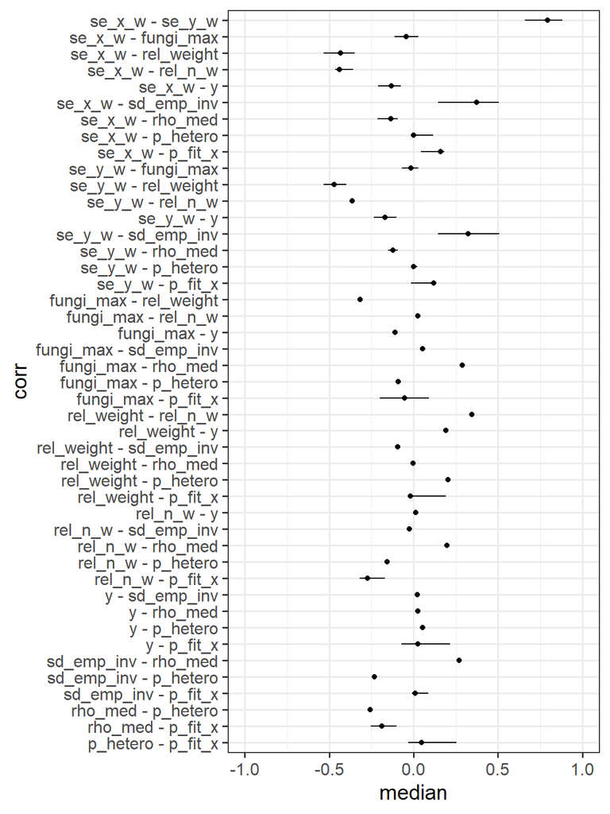

The following table lists the correlation ordered by largest absolute minimum:

```
## # A tibble: 45 x 6
##    corr                     min   max median  mean     sd
##    <fct>                  <dbl> <dbl>  <dbl> <dbl>  <dbl>
##  1 se_x_w - se_y_w         0.66  0.88   0.80  0.79 0.078
##  2 se_y_w - rel_weight    -0.53 -0.40  -0.47 -0.47 0.073
##  3 se_x_w - rel_weight    -0.53 -0.35  -0.43 -0.43 0.072
##  4 se_x_w - rel_n_w       -0.46 -0.36  -0.44 -0.42 0.047
##  5 se_y_w - rel_n_w       -0.37 -0.36  -0.36 -0.36 0.0077
##  6 rel_weight - rel_n_w    0.34  0.35   0.35  0.35 0.0011
##  7 fungi_max - rel_weight -0.32 -0.31  -0.32 -0.32 0.0018
##  8 rel_n_w - p_fit_x      -0.32 -0.17  -0.27 -0.27 0.054
##  9 fungi_max - rho_med     0.29  0.30   0.29  0.29 0.0046
## 10 sd_emp_inv - rho_med    0.27  0.27   0.27  0.27 0.0012
## # ... with 35 more rows
```

The following table lists the correlation ordered by largest absolute maximum:

```
## # A tibble: 45 x 6
##    corr                     min   max median  mean     sd
##    <fct>                  <dbl> <dbl>  <dbl> <dbl>  <dbl>
##  1 se_x_w - se_y_w         0.66  0.88   0.80  0.79 0.078
##  2 se_y_w - sd_emp_inv     0.15  0.51   0.32  0.32 0.20
##  3 se_x_w - sd_emp_inv     0.15  0.50   0.37  0.36 0.15
##  4 se_y_w - rel_weight    -0.53 -0.40  -0.47 -0.47 0.073
##  5 se_x_w - rel_n_w       -0.46 -0.36  -0.44 -0.42 0.047
##  6 se_y_w - rel_n_w       -0.37 -0.36  -0.36 -0.36 0.0077
##  7 se_x_w - rel_weight    -0.53 -0.35  -0.43 -0.43 0.072
##  8 rel_weight - rel_n_w    0.34  0.35   0.35  0.35 0.0011
##  9 fungi_max - rel_weight -0.32 -0.31  -0.32 -0.32 0.0018
## 10 fungi_max - rho_med     0.29  0.30   0.29  0.29 0.0046
## # ... with 35 more rows
```

The following table lists the correlation ordered by largest absolute median:

```
## # A tibble: 45 x 6
##    corr                      min    max median  mean      sd
##    <fct>                   <dbl>  <dbl>  <dbl> <dbl>   <dbl>
##  1 se_x_w - se_y_w         0.66   0.88    0.80  0.79 0.078
##  2 se_y_w - rel_weight    -0.53  -0.40   -0.47 -0.47 0.073
##  3 se_x_w - rel_n_w       -0.46  -0.36   -0.44 -0.42 0.047
##  4 se_x_w - rel_weight    -0.53  -0.35   -0.43 -0.43 0.072
##  5 se_x_w - sd_emp_inv     0.15   0.50    0.37  0.36 0.15
##  6 se_y_w - rel_n_w       -0.37  -0.36   -0.36 -0.36 0.0077
##  7 rel_weight - rel_n_w    0.34   0.35    0.35  0.35 0.0011
##  8 se_y_w - sd_emp_inv     0.15   0.51    0.32  0.32 0.20
##  9 fungi_max - rel_weight -0.32  -0.31   -0.32 -0.32 0.0018
## 10 fungi_max - rho_med     0.29   0.30    0.29  0.29 0.0046
## 11 rel_n_w - p_fit_x      -0.32  -0.17   -0.27 -0.27 0.054
## 12 sd_emp_inv - rho_med    0.27   0.27    0.27  0.27 0.0012
## 13 rho_med - p_hetero     -0.26  -0.26   -0.26 -0.26 0.0012
## 14 sd_emp_inv - p_hetero  -0.23  -0.23   -0.23 -0.23 0.0040
## 15 rel_weight - p_hetero   0.19   0.20    0.20  0.20 0.0067
## 16 rel_n_w - rho_med       0.20   0.20    0.20  0.20 0.00090
## 17 rel_weight - y          0.19   0.19    0.19  0.19 0.0011
## 18 rho_med - p_fit_x      -0.25  -0.099  -0.19 -0.18 0.077
## 19 se_y_w - y             -0.23  -0.10   -0.17 -0.17 0.071
## 20 se_x_w - p_fit_x        0.044  0.18    0.16  0.14 0.054
## # ... with 25 more rows
```

# Multiple Regression

We then consider multiple regression models.

Here, we first consider several model variants (in addition to the baseline model, `mean`, and the `parameter` model) of the nine moderators (there are ten moderators initially, and because we combine both standard error estimates we end up with nine). As further possible models we also consider a model with both separate standard errors, `mse_both` (entered as main effects) and one with only the combined standard error (`mse_c`). Also, for the estimate itself (`y`) we consider a linear and quadratic trend which is why we add two coefficients for this moderator in each model. Also, we always use the same transformation as presented in the figures in the paper (e.g., log for relative information). The following additional models are included:

- `main`: Main effects only (i.e., all effects are additive)
- `main_good`: Main effects of the four “good” moderators (SE, parameter trade-offs, relative information, and relative N).
- `inter_2`: main effects and second order interactions of all moderators.
- `inter_2_godd`: main effects and second order interactions of the four “good” moderators.
- `best2` best model with two moderators as main effects (one of which is the combined standard error)
- `best3` best model with three moderators as main effects (one of which is the combined standard error)
- `se_y_fungi`: standard error, value of the estimate, and parameter trade-off
- `se_y`: standard error and value of the estimate

These models have the following numbers of parameters.

```
## # A tibble: 14 x 14
##    cond_label  cond_iv_label  mean parameter mse_both mse_c  main main_good inter_2 inter_2_good se_y_fungi  se_y best2 best3
##    <fct>       <fct>         <dbl>     <dbl>    <dbl> <dbl> <dbl>     <dbl>   <dbl>        <dbl>      <dbl> <dbl> <dbl> <dbl>
##  1 DV: Comp M~ IV: Comp Bay~     1        49        3     2    11         5      55           11          5     4     4     5
##  2 DV: Comp M~ IV: No asy        1        49        3     2    11         5      55           11          5     4     4     5
##  3 DV: Comp M~ IV: No PB         1        49        3     2    11         5      55           11          5     4     4     5
##  4 DV: Comp M~ IV: No NPB        1        49        3     2    11         5      55           11          5     4     4     5
##  5 DV: Comp M~ IV: Beta PP       1        49        3     2    11         5      55           11          5     4     4     5
##  6 DV: Comp M~ IV: Trait_u ~     1        49        3     2    11         5      55           11          5     4     3     4
##  7 DV: Comp M~ IV: Trait PP      1        49        3     2    11         5      55           11          5     4     4     5
##  8 DV: Trait ~ IV: Comp MLE      1        49        3     2    11         5      55           11          5     4     4     5
##  9 DV: Trait ~ IV: Comp Bay~     1        49        3     2    11         5      55           11          5     4     3     5
## 10 DV: Trait ~ IV: No asy        1        49        3     2    11         5      55           11          5     4     4     5
## 11 DV: Trait ~ IV: No PB         1        49        3     2    11         5      55           11          5     4     4     5
## 12 DV: Trait ~ IV: No NPB        1        49        3     2    11         5      55           11          5     4     4     5
## 13 DV: Trait ~ IV: Beta PP       1        49        3     2    11         5      55           11          5     4     4     5
## 14 DV: Trait ~ IV: Trait_u ~     1        49        3     2    11         5      55           11          5     4     3     4
```

The following table shows the resulting RMSE for all models.

```
## # A tibble: 14 x 14
##    cond_label  cond_iv_label  mean parameter mse_both mse_c  main main_good inter_2 inter_2_good se_y_fungi  se_y best2 best3
##    <fct>       <fct>         <dbl>     <dbl>    <dbl> <dbl> <dbl>     <dbl>   <dbl>        <dbl>      <dbl> <dbl> <dbl> <dbl>
##  1 DV: Comp M~ IV: Comp Bay~ 0.070     0.067    0.069 0.069 0.067     0.069   0.061        0.069      0.068 0.068 0.068 0.067
##  2 DV: Comp M~ IV: No asy    0.050     0.037    0.039 0.041 0.036     0.038   0.030        0.037      0.038 0.039 0.039 0.037
##  3 DV: Comp M~ IV: No PB     0.071     0.054    0.053 0.057 0.051     0.054   0.047        0.051      0.054 0.054 0.054 0.053
##  4 DV: Comp M~ IV: No NPB    0.056     0.043    0.042 0.046 0.041     0.044   0.038        0.042      0.043 0.044 0.044 0.042
##  5 DV: Comp M~ IV: Beta PP   0.035     0.027    0.030 0.031 0.027     0.029   0.023        0.028      0.028 0.029 0.029 0.028
##  6 DV: Comp M~ IV: Trait_u ~ 0.033     0.025    0.029 0.029 0.024     0.027   0.021        0.026      0.028 0.028 0.027 0.026
##  7 DV: Comp M~ IV: Trait PP  0.038     0.031    0.032 0.032 0.029     0.030   0.026        0.030      0.030 0.031 0.031 0.030
##  8 DV: Trait ~ IV: Comp MLE  0.038     0.031    0.032 0.032 0.029     0.030   0.026        0.030      0.030 0.031 0.031 0.030
##  9 DV: Trait ~ IV: Comp Bay~ 0.073     0.069    0.071 0.072 0.069     0.072   0.064        0.072      0.071 0.071 0.071 0.070
## 10 DV: Trait ~ IV: No asy    0.049     0.036    0.043 0.044 0.039     0.043   0.034        0.042      0.040 0.041 0.041 0.040
## 11 DV: Trait ~ IV: No PB     0.070     0.056    0.061 0.061 0.055     0.059   0.050        0.058      0.057 0.057 0.057 0.057
## 12 DV: Trait ~ IV: No NPB    0.052     0.043    0.046 0.046 0.042     0.045   0.038        0.044      0.043 0.043 0.043 0.043
## 13 DV: Trait ~ IV: Beta PP   0.035     0.030    0.032 0.033 0.028     0.031   0.024        0.030      0.030 0.031 0.030 0.029
## 14 DV: Trait ~ IV: Trait_u ~ 0.024     0.019    0.020 0.020 0.018     0.019   0.015        0.017      0.020 0.020 0.020 0.019
```

We can also reduce this table to only the comparison methods selected in the paper:

```
## # A tibble: 6 x 14
##   cond_label   cond_iv_label  mean parameter mse_both mse_c  main main_good inter_2 inter_2_good se_y_fungi  se_y best2 best3
##   <fct>        <fct>         <dbl>     <dbl>    <dbl> <dbl> <dbl>     <dbl>   <dbl>        <dbl>      <dbl> <dbl> <dbl> <dbl>
## 1 DV: Comp MLE IV: No asy    0.050     0.037    0.039 0.041 0.036     0.038   0.030        0.037      0.038 0.039 0.039 0.037
## 2 DV: Comp MLE IV: Beta PP   0.035     0.027    0.030 0.031 0.027     0.029   0.023        0.028      0.028 0.029 0.029 0.028
## 3 DV: Comp MLE IV: Trait PP  0.038     0.031    0.032 0.032 0.029     0.030   0.026        0.030      0.030 0.031 0.031 0.030
## 4 DV: Trait PP IV: Comp MLE  0.038     0.031    0.032 0.032 0.029     0.030   0.026        0.030      0.030 0.031 0.031 0.030
## 5 DV: Trait PP IV: No asy    0.049     0.036    0.043 0.044 0.039     0.043   0.034        0.042      0.040 0.041 0.041 0.040
## 6 DV: Trait PP IV: Beta PP   0.035     0.030    0.032 0.033 0.028     0.031   0.024        0.030      0.030 0.031 0.030 0.029
```

The results show that the model with all `main` effects usually provides an account that is very similar to the `parameter` model. The model only containing the “good” moderators fares slightly worse but not much. Even including interaction does not bring too much, akthough including all adds many parameters.

The following table shows the additional variable in the model with the best two moderators and the two additional predictors in the model with the best three moderators.

```
## # A tibble: 6 x 7
##   cond_label   cond_iv_label  b2_1  b2_2    b3_1  b3_2    b3_3
##   <fct>        <fct>          <chr> <chr>   <chr> <chr>   <chr>
## 1 DV: Comp MLE IV: No PB      se_c  y_c     se_c  y_c     rel_n_w
## 2 DV: Comp MLE IV: Trait PP   se_c  y_c     se_c  y_c     rel_n_w
## 3 DV: Comp MLE IV: Beta PP    se_c  y_c     se_c  y_c     rel_n_w
## 4 DV: Trait PP IV: Comp MLE   se_c  y_c     se_c  y_c     rel_n_w
## 5 DV: Trait PP IV: No PB      se_c  y_c     se_c  y_c     fungi_max
## 6 DV: Trait PP IV: Trait_u PP se_c  rel_n_w se_c  rel_n_w fungi_max
```

The following plot shows the coeffcicients for the model with SE, value (linear and quadratic) and fungibility.

```
## # A tibble: 5 x 3
##   term           mean median
##   <fct>         <dbl>  <dbl>
## 1 Trade-offs    0.047  0.046
## 2 Value (quad)  0.17   0.17
## 3 Value (lin)  -0.013 -0.010
## 4 SE            0.58   0.52
## 5 Intercept    -0.021 -0.019
```

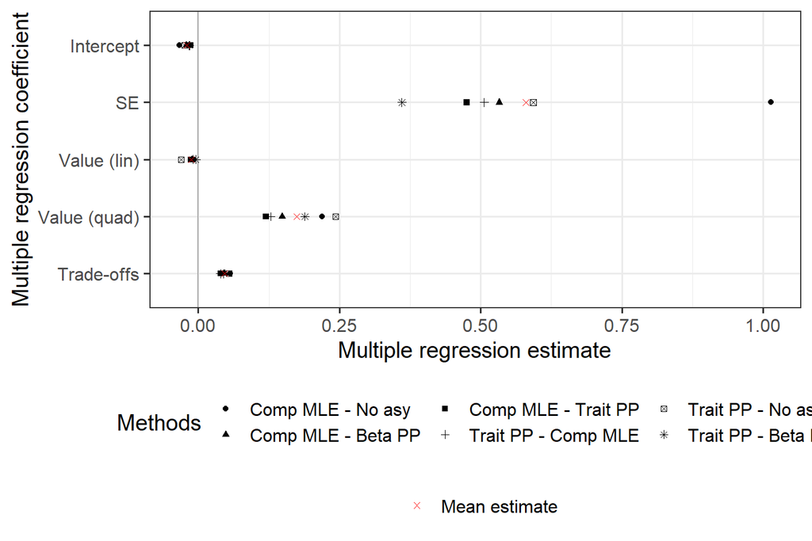

Overview of correlations in model with three best coefficients:

```
## # A tibble: 6 x 6
##   corr                    min     max median   mean     sd
##   <fct>                 <dbl>   <dbl>  <dbl>  <dbl>  <dbl>
## 1 y_c_quad - fungi_max -0.081 -0.063  -0.075 -0.074 0.0085
## 2 y_c - fungi_max      -0.13  -0.099  -0.11  -0.11  0.012
## 3 y_c - y_c_quad       -0.14  -0.11   -0.12  -0.12  0.016
## 4 se_c - fungi_max     -0.082  0.0052 -0.032 -0.037 0.029
## 5 se_c - y_c_quad      -0.23  -0.0093 -0.11  -0.12  0.095
## 6 se_c - y_c           -0.21  -0.099  -0.16  -0.16  0.041
```

# RAMP Model selection

RAMP results for selected method pairs (`rmsec`) and number of coefficients in RAMP model:

```
## # A tibble: 6 x 10
##   cond_label   cond_iv_label r      r_c    data                   rmse rmsec main      inter          n
##   <fct>        <fct>         <list> <list> <list>                <dbl> <dbl> <list>    <list>     <dbl>
## 1 DV: Comp MLE IV: No asy    <RAMP> <RAMP> <tibble [1,364 x 69]> 0.034 0.032 <int [7]> <chr [17]>    25
## 2 DV: Comp MLE IV: Beta PP   <RAMP> <RAMP> <tibble [1,349 x 69]> 0.023 0.023 <int [7]> <chr [17]>    25
## 3 DV: Comp MLE IV: Trait PP  <RAMP> <RAMP> <tibble [1,364 x 69]> 0.028 0.027 <int [5]> <chr [6]>     12
## 4 DV: Trait PP IV: Comp MLE  <RAMP> <RAMP> <tibble [1,364 x 69]> 0.027 0.028 <int [5]> <chr [8]>     14
## 5 DV: Trait PP IV: No asy    <RAMP> <RAMP> <tibble [1,372 x 69]> 0.034 0.034 <int [8]> <chr [27]>    36
## 6 DV: Trait PP IV: Beta PP   <RAMP> <RAMP> <tibble [1,357 x 69]> 0.024 0.025 <int [6]> <chr [15]>    22
```

Inclusion probability of interactions (only selected method pairs):

```
##                 se_c fungi_max log.rel_weight. log.rel_n_w.  y_c sd_emp_inv rho_med log1p.p_hetero. log1p.p_fit_x.
## se_c             0.5      0.50            0.33         0.50 0.67       0.33    0.00            0.17           0.50
## fungi_max        0.0      0.67            0.33         1.00 0.67       0.50    0.00            0.33           0.50
## log.rel_weight.  0.0      0.00            0.00         0.33 0.33       0.33    0.00            0.00           0.17
## log.rel_n_w.     0.0      0.00            0.00         0.83 0.00       1.00    0.00            0.33           0.50
## y_c              0.0      0.00            0.00         0.00 1.00       0.33    0.00            0.33           0.33
## sd_emp_inv       0.0      0.00            0.00         0.00 0.00       0.67    0.17            0.00           0.50
## rho_med          0.0      0.00            0.00         0.00 0.00       0.00    0.00            0.00           0.17
## log1p.p_hetero.  0.0      0.00            0.00         0.00 0.00       0.00    0.00            0.00           0.00
## log1p.p_fit_x.   0.0      0.00            0.00         0.00 0.00       0.00    0.00            0.00           0.17
```

```
## [1] 3
```

```
## [1] 1
```

```
## [1] 4
```

```
## [1] 8
```

```
## [1] 11
```

```
## [1] 5
```

```
## [1] 13
```

```
## [1] 45
```

Inclusion vector of main effects

```
##            se_c       fungi_max log.rel_weight.    log.rel_n_w.             y_c      sd_emp_inv         rho_med
##       1.0000000       1.0000000       0.3333333       1.0000000       1.0000000       1.0000000       0.1666667
## log1p.p_hetero.  log1p.p_fit_x.
##       0.3333333       0.5000000
```

RAMP results for all method pairs:

```
## # A tibble: 14 x 9
##    cond_label   cond_iv_label  r      r_c    data                   rmse rmsec main      inter
##    <fct>        <fct>          <list> <list> <list>                <dbl> <dbl> <list>    <list>
##  1 DV: Comp MLE IV: Comp Bayes <RAMP> <RAMP> <tibble [1,364 x 69]> 0.061 0.062 <int [5]> <chr [7]>
##  2 DV: Comp MLE IV: No asy     <RAMP> <RAMP> <tibble [1,364 x 69]> 0.034 0.032 <int [7]> <chr [17]>
##  3 DV: Comp MLE IV: No PB      <RAMP> <RAMP> <tibble [1,327 x 69]> 0.049 0.049 <int [5]> <chr [3]>
##  4 DV: Comp MLE IV: No NPB     <RAMP> <RAMP> <tibble [1,318 x 69]> 0.040 0.040 <int [5]> <chr [4]>
##  5 DV: Comp MLE IV: Beta PP    <RAMP> <RAMP> <tibble [1,349 x 69]> 0.023 0.023 <int [7]> <chr [17]>
##  6 DV: Comp MLE IV: Trait_u PP <RAMP> <RAMP> <tibble [1,175 x 69]> 0.022 0.021 <int [7]> <chr [16]>
##  7 DV: Comp MLE IV: Trait PP   <RAMP> <RAMP> <tibble [1,364 x 69]> 0.028 0.027 <int [5]> <chr [6]>
##  8 DV: Trait PP IV: Comp MLE   <RAMP> <RAMP> <tibble [1,364 x 69]> 0.027 0.028 <int [5]> <chr [8]>
##  9 DV: Trait PP IV: Comp Bayes <RAMP> <RAMP> <tibble [1,372 x 69]> 0.064 0.063 <int [9]> <chr [14]>
## 10 DV: Trait PP IV: No asy     <RAMP> <RAMP> <tibble [1,372 x 69]> 0.034 0.034 <int [8]> <chr [27]>
## 11 DV: Trait PP IV: No PB      <RAMP> <RAMP> <tibble [1,335 x 69]> 0.052 0.052 <int [6]> <chr [8]>
## 12 DV: Trait PP IV: No NPB     <RAMP> <RAMP> <tibble [1,323 x 69]> 0.040 0.038 <int [7]> <chr [19]>
## 13 DV: Trait PP IV: Beta PP    <RAMP> <RAMP> <tibble [1,357 x 69]> 0.024 0.025 <int [6]> <chr [15]>
## 14 DV: Trait PP IV: Trait_u PP <RAMP> <RAMP> <tibble [1,179 x 69]> 0.014 0.015 <int [6]> <chr [16]>
```

Inclusion of interaction for all method pairs:

```
##                 se_c fungi_max log.rel_weight. log.rel_n_w.  y_c sd_emp_inv rho_med log1p.p_hetero. log1p.p_fit_x.
## se_c            0.43      0.36            0.21         0.64 0.79       0.29    0.07            0.14           0.43
## fungi_max       0.00      0.57            0.29         0.57 0.50       0.29    0.07            0.14           0.36
## log.rel_weight. 0.00      0.00            0.00         0.36 0.29       0.21    0.00            0.00           0.29
## log.rel_n_w.    0.00      0.00            0.00         0.50 0.29       0.64    0.07            0.14           0.50
## y_c             0.00      0.00            0.00         0.00 0.93       0.43    0.00            0.21           0.29
## sd_emp_inv      0.00      0.00            0.00         0.00 0.00       0.50    0.14            0.00           0.29
## rho_med         0.00      0.00            0.00         0.00 0.00       0.00    0.07            0.00           0.07
## log1p.p_hetero. 0.00      0.00            0.00         0.00 0.00       0.00    0.00            0.00           0.07
## log1p.p_fit_x.  0.00      0.00            0.00         0.00 0.00       0.00    0.00            0.00           0.21
```